# 12 Modern Optimization

Here, we explore the use of Simulated Annealing for three examples.

- The Rastrigin function
- A constrained optimization problem
- Portfolio optimization problem

First load the required packages.

Ref: Generalized Simulated Annealing for Global Optimization: The GenSA Package An Application to Non-Convex Optimization in Finance and Physics by Yang Xiang, Sylvain Gubian, Brian Suomela and Julia Hoeng

```r
library(GenSA)
library(ggplot2)
library(GA)
```

# Rastrigin Function

Let us now apply SA to the Rastrigin function in two dimensions

```r
Rastrigin <- function(x, y) {
   x^2 + y^2 - 10 * (cos(2 * pi * x) + cos(2 * pi * y) - 2)
}
obj = function(z) {Rastrigin(z[1],z[2])}
lower <- c(-4,-4)
upper <- c(4,4)
par <- c(2,2)
```

## Plot the function

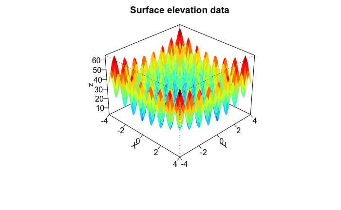

```r
# Plot the function
x=seq(-4,4,length=50) # tick marks on x axis
y=seq(-4,4,length=50) # tick marks on y axis; defines grid for...
z=outer(x,y,Rastrigin) # matrix for plotting -- z vals / height of surface
 persp3D(x, y, z, phi = 30, theta = 45,
  xlab = "X", ylab = "Y",
  main = "Surface elevation data",
  color.palette = bl2gr.colors
)
```

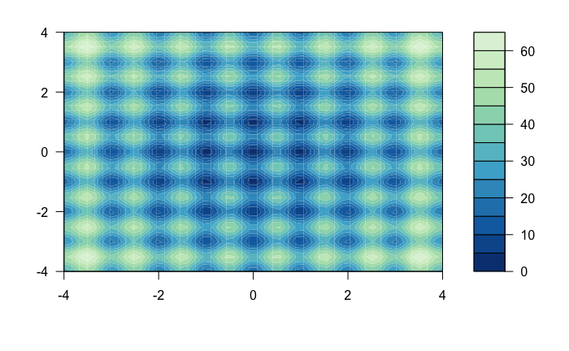

```r
filled.contour(x, y, z, color.palette = bl2gr.colors)
```

## Solve the Rastrigin problem using SA

```r
expected.val <- 0
absTol <- 1e-13
fn.call <- 0
out <- GenSA(par=par,lower=lower,upper=upper,fn=obj)
out[c("value","par","counts")]
```

```
$value
[1] 8.962034e-30

$par
[1]  2.251884e-15 -1.972575e-15

$counts
[1] 51510
```

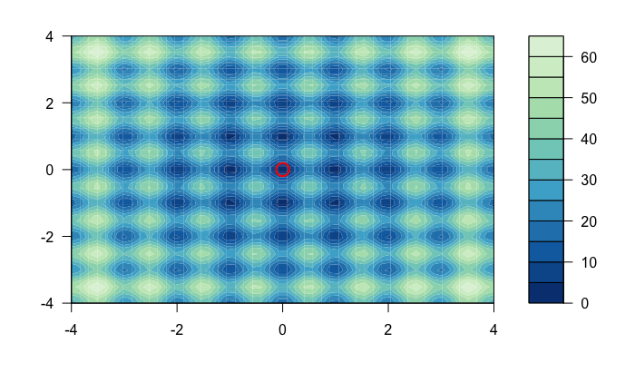

```r
filled.contour(x, y, z, color.palette = bl2gr.colors,
      plot.axes = { axis(1);
                    axis(2); points(out$par[1],out$par[2],
                                    cex=2,col="red",lwd=2)}
)
```

The optimal solution has been identified by GenSA.

# Constrained optimization

Let us now take the second example, which is an example of constrained optimization. As we mentioned in the lectures, many times we convert constrained optimization to unconstrained optimization by including the constraints as part of the objective function. In this case, our constraints only set limits on x, and we can include that as part of the optimization.

## Define the function and limits

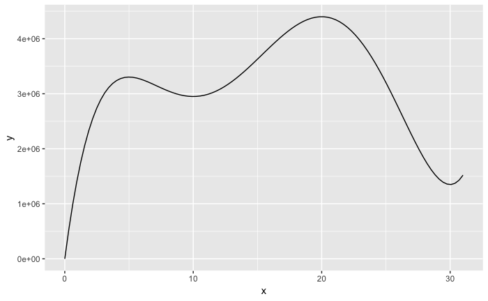

```r
 nfun = function(x) {
   (12*x^5-975*x^4+28000*x^3-345000*x^2+1800000*x)
 }
ll = c(0)
ul = c(31)
# Plot the function
# Note, plotting as a maximization function
p <- ggplot(data=data.frame(x=0),aes(x=x))
p + stat_function(fun=nfun) + xlim(0,31)
```

## Solve using GenSA

Note that GenSA only solves minimization problems by default

```r
nfun1 = function(x) { -nfun(x)} # convert to minimization
ll = c(0)
ul = c(31)
par = 2
out1 <- GenSA(par=par,lower=ll,upper=ul,fn=nfun1)
out1[c("value","par","counts")]
```

```
$value
[1] -4400000

$par
[1] 20

$counts
[1] 53715
```

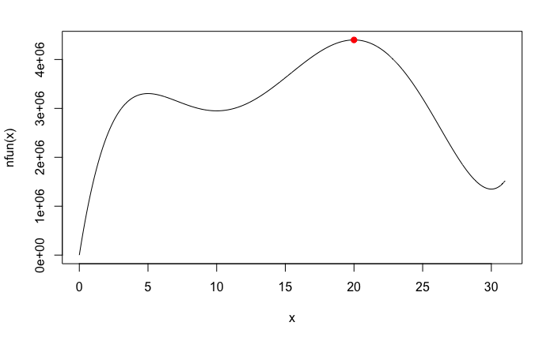

```r
curve(nfun, from = 0, to = 31, n = 1000)
points(out1$par[1],-out1$value, col = 2, pch = 19)
```

The optimal solution has been identified as x = 20.

# Portfolio Optimization

For our last example, we will use a portfolio optimization example. Please read

Reference:

- https://cran.r-project.org/web/packages/PortfolioAnalytics/vignettes/portfolio_vignette.pdf
- https://journal.r-project.org/archive/2013/RJ-2013-002/RJ-2013-002.pdf

Mean-risk models were developed in the 1950s for portfolio selection problems. Value-at-Risk (VaR) and Conditional Value-at-Risk (CVaR) are the most popular measures of downside risk. Mullen et al. (2011) and Ardia et al. (2011) used DEoptim to find the portfolio weights for which the portfolio has the lowest CVaR and each investment can contribute at most 22.5% to total portfolio CVaR risk. For details, please refer to Mullen et al. (2011); Ardia et al. (2011). The code for objective function in portfolio optimization are from Ardia et al. (2011) (https://journal.r-project.org/archive/2011/RJ-2011-005/RJ-2011-005.pdf)  
Definition of VAR/CVAR: http://www.pacca.info/public/files/docs/public/finance/Active%20Risk%20Management/gpfl.pdf

```r
pContribCVaR
```

```
[1] 0.1852036 0.1351591 0.2002548 0.2611494 0.2182331
```

Looking at the results we see that in this equal-weight portfolio, a 20% investment in AMZN causes 26.11% of the CVaR risk in the portfolio, while a 20% investment in IBM only causes a 13.52% risk. This is probably because of the high standard deviation 10.46, in percent, of AMZN compared to IBM, 5.59.

Let us now calculate the weights of this portfolio to minimize CVaR for the portfolio, where each investment can only contribute at most 22.5%

## Solve using GenSA

```r
set.seed(43298)
fn.call <<- 0
out.GenSA <- GenSA(fn = obj, lower = rep(0, 5), upper = rep(1, 5), control = list(smooth = FALSE, max.call = 3000))
```

[output not shown]

[output cut: 2945 more lines]

[output not shown]

```r
fn.call.GenSA <- fn.call
out.GenSA$par # This gives the weights
```

```
[1] 0.7133836 0.9714053 0.7122641 0.2950518 0.6378106
```

```r
out.GenSA$value # objective function value
```

```
[1] 0.1021233
```

```r
#out.GenSA$counts
cat("GenSA call functions", fn.call.GenSA, "times.\n")
```

```
GenSA call functions 3000 times.
```

```r
wstar.GenSA <- out.GenSA$par
wstar.GenSA <- wstar.GenSA / sum(wstar.GenSA) # standardize the weights
cat("Weights in minimum-risk portolio \n")
```

```
Weights in minimum-risk portolio
```

```r
rbind(tickers, round(100 * wstar.GenSA, 2))
```

```
        [,1]    [,2]    [,3]    [,4]   [,5]
tickers "GE"    "IBM"   "GOOG"  "AMZN" "AAPL"
        "21.42" "29.17" "21.39" "8.86" "19.15"
```

```r
cat("Return for equal weights portfolio = ",round(mu*100, 2),"\n")
```

```
Return for equal weights portfolio =  -0.71 0.14 1.45 2.18 2.32
```

```r
cat("Average return for equal weights portfolio = ",round(mean(mu)*100,2),"\n") # This specifies the return for an equal weight portfolio
```

```
Average return for equal weights portfolio =  1.08
```

```r
cat("Expected return compared to equal-weights portfolio = ",100 * (sum(wstar.GenSA * mu) - mean(mu)),"\n") # A positive value here indicates that this portfolio will have higher expected return than an equal weight portfolio
```

```
Expected return compared to equal-weights portfolio =  -0.2389105
```

Note the relatively low weight given to AMZN (8.86), and the large weight for IBM (29.17) in this, compared to the equal weights portfolio. This minimum risk portfolio, however, does not have a higher expected return than the equal-weights portfolio. It is possible to modify our objective criteria to address this. Please see https://journal.r-project.org/archive/2011/RJ-2011-005/RJ-2011-005.pdf for additional insight.

# Portfolio Optimization using Genetic Algorithms

```r
# Note the - sign in the fitness function
# https://cran.r-project.org/web/packages/GA/vignettes/GA.html
outGA <- ga(type = "real-valued",fitness= objmin ,lower=rep(0,5),upper=rep(1,5),popSize = 100)
```

[output not shown]

[output cut: 45 more lines]

[output not shown]

```r
-1*outGA@fitnessValue
```

```
[1] 0.1026579
```

```r
wstar.GA <- outGA@solution # Weights
wstar.GA <- wstar.GA / sum(wstar.GA)
rbind(tickers,round(100*wstar.GA,2))
```

```
        x1     x2      x3      x4      x5
tickers "GE"   "IBM"   "GOOG"  "AMZN"  "AAPL"
        "21.3" "28.81" "19.13" "12.61" "18.15"
```

```r
100 * (sum(wstar.GA*mu)-mean(mu))
```

```
[1] -0.2128918
```

Note that the solution here differs slightly from that obtained with SA.